# Cheat Sheet for data.table

Author: Rick Dean

Article date: 2022-01-21

Abstract

The following contains notes/R scripts on learning data.table from a this [cheat sheet](https://s3.amazonaws.com/assets.datacamp.com/img/blog/data+table+cheat+sheet.pdf). Described as the official cheat sheet for the DataCamp course.

```r
library(knitr)
library(data.table)
```

# Data Analysis the Data.Table Way

## Example data.table

### Create the data.table *DT*

```r
DT <- data.table(
  V1 = c(1L, 2L),
  V2 = LETTERS[1:3],
  V3 = round(rnorm(4), 4),
  V4 = 1:12
)
DT
```

```
##     V1 V2      V3 V4
##  1:  1  A -0.1771  1
##  2:  2  B  1.3976  2
##  3:  1  C -0.1400  3
##  4:  2  A  0.4712  4
##  5:  1  B -0.1771  5
##  6:  2  C  1.3976  6
##  7:  1  A -0.1400  7
##  8:  2  B  0.4712  8
##  9:  1  C -0.1771  9
## 10:  2  A  1.3976 10
## 11:  1  B -0.1400 11
## 12:  2  C  0.4712 12
```

Note: the recycling

### Define a function for resetting *DT*

```r
reset_DT = function(){
  DT <- data.table(
    V1 = c(1L, 2L),
    V2 = LETTERS[1:3],
    V3 = round(rnorm(4), 4),
    V4 = 1:12
  )
  return(DT)
}
```

## Subsetting rows using `i`

### By numbers

```r
DT[3:5,] # or DT[3:5]
```

```
##    V1 V2      V3 V4
## 1:  1  C -0.1400  3
## 2:  2  A  0.4712  4
## 3:  1  B -0.1771  5
```

### By column name

```r
DT[V2 == "A"] # selects all rows that have value "A"
```

```
##    V1 V2      V3 V4
## 1:  1  A -0.1771  1
## 2:  2  A  0.4712  4
## 3:  1  A -0.1400  7
## 4:  2  A  1.3976 10
```

### By multiple column name

```r
DT[V2 %in% c("A", "C")] # all rows that have "A" or "C" in column V2
```

```
##    V1 V2      V3 V4
## 1:  1  A -0.1771  1
## 2:  1  C -0.1400  3
## 3:  2  A  0.4712  4
## 4:  2  C  1.3976  6
## 5:  1  A -0.1400  7
## 6:  1  C -0.1771  9
## 7:  2  A  1.3976 10
## 8:  2  C  0.4712 12
```

## Manipulating on columns in `j`

### Select one column in `j`

```r
DT[, V2]
```

```
##  [1] "A" "B" "C" "A" "B" "C" "A" "B" "C" "A" "B" "C"
```

### Select several columns in `j` use `.()`

```r
DT[, .(V2, V3)] # returns a data.table
```

```
##     V2      V3
##  1:  A -0.1771
##  2:  B  1.3976
##  3:  C -0.1400
##  4:  A  0.4712
##  5:  B -0.1771
##  6:  C  1.3976
##  7:  A -0.1400
##  8:  B  0.4712
##  9:  C -0.1771
## 10:  A  1.3976
## 11:  B -0.1400
## 12:  C  0.4712
```

Note: `.()` is alias to `list()`. If `.()` is used the returned value is a *data.table*. If `.()` is not used the result is a vector.

### Select columns without using `.()`

```r
DT[, c(V2,V3)] # returns a vector
```

```
##  [1] "A"       "B"       "C"       "A"       "B"       "C"       "A"       "B"       "C"       "A"       "B"       "C"       "-0.1771"
## [14] "1.3976"  "-0.14"   "0.4712"  "-0.1771" "1.3976"  "-0.14"   "0.4712"  "-0.1771" "1.3976"  "-0.14"   "0.4712"
```

### Call functions in `j`

```r
DT[, sum(V1)] # returns the sum of all elements in V1 as a vector
```

```
## [1] 18
```

### Computing on several columns

```r
DT[, .(sum(V1), sd(V3))] # returns sum of V1 and sd of V3 in a data.table
```

```
##    V1        V2
## 1: 18 0.6655831
```

### Assigning column names to computed columns

```r
DT[, .(Aggregate = sum(V1), Sd.V3 = sd(V3))]
```

```
##    Aggregate     Sd.V3
## 1:        18 0.6655831
```

### Columns get recycled if different lengths

```r
DT[, .(V1, Sd.V3 = sd(V3))] # Sd.V3 gets recycled
```

```
##     V1     Sd.V3
##  1:  1 0.6655831
##  2:  2 0.6655831
##  3:  1 0.6655831
##  4:  2 0.6655831
##  5:  1 0.6655831
##  6:  2 0.6655831
##  7:  1 0.6655831
##  8:  2 0.6655831
##  9:  1 0.6655831
## 10:  2 0.6655831
## 11:  1 0.6655831
## 12:  2 0.6655831
```

### Multiple expressions wrapped in curly braces

```
##  [1] "A" "B" "C" "A" "B" "C" "A" "B" "C" "A" "B" "C"
```

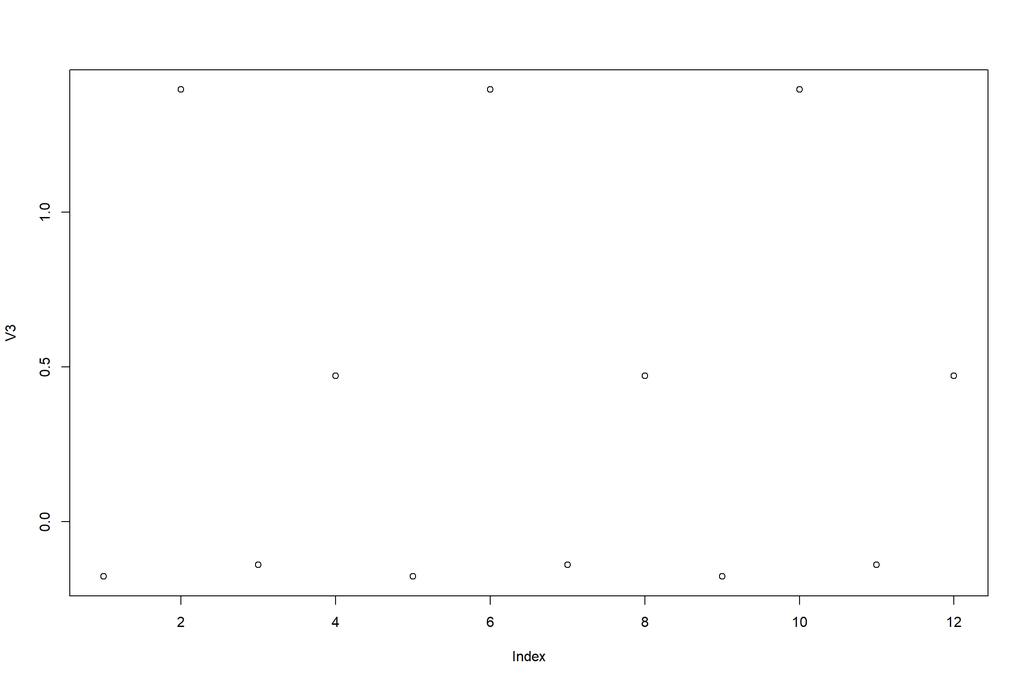

```r
DT[, {print(V2)  # like in-line funciton
      plot(V3)
      NULL}]
```

## Grouping with `j`

### Doing grouping with one column

```r
DT[, .(V4.Sum = sum(V4)), by = V1] # the sum of V4 for every group in V1
```

```
##    V1 V4.Sum
## 1:  1     36
## 2:  2     42
```

### Doing grouping with a function in `j`

```r
DT[, .(V4.mean = mean(V4)), by = V2] # the mean of V4 in subgroups of V2
```

```
##    V2 V4.mean
## 1:  A     5.5
## 2:  B     6.5
## 3:  C     7.5
```

### Doing grouping with several columns using `.()`

```r
DT[, .(V4.Sum = sum(V4)), by = .(V1,V2)]
```

```
##    V1 V2 V4.Sum
## 1:  1  A      8
## 2:  2  B     10
## 3:  1  C     12
## 4:  2  A     14
## 5:  1  B     16
## 6:  2  C     18
```

### Call functions in `by`

```r
DT[, .(V4.Sum = sum(V4)), by = sign(V1-1)]
```

```
##    sign V4.Sum
## 1:    0     36
## 2:    1     42
```

### Assigning new column names in `by`

```r
DT[, .(V4.Sum = sum(V4)), by = .(V1.01 = sign(V1-1))]
```

```
##    V1.01 V4.Sum
## 1:     0     36
## 2:     1     42
```

### Grouping on only a subset of rows by specifying `i`

```r
DT[1:5, .(V4.Sum = sum(V4)), by = V1]
```

```
##    V1 V4.Sum
## 1:  1      9
## 2:  2      6
```

### Using `.N` to get the total number of rows for each group

```r
DT[, .N, by = V1]
```

```
##    V1 N
## 1:  1 6
## 2:  2 6
```

### Using `.N` in `j` returns the number of rows

```r
DT[,.N]
```

```
## [1] 12
```

## Adding/Updating columns by reference in `j` using `:=`

### Updating one column using `:=`

```r
DT[, V1 := round(exp(V1), 2)] # V1 is updated
DT
```

```
##       V1 V2      V3 V4
##  1: 2.72  A -0.1771  1
##  2: 7.39  B  1.3976  2
##  3: 2.72  C -0.1400  3
##  4: 7.39  A  0.4712  4
##  5: 2.72  B -0.1771  5
##  6: 7.39  C  1.3976  6
##  7: 2.72  A -0.1400  7
##  8: 7.39  B  0.4712  8
##  9: 2.72  C -0.1771  9
## 10: 7.39  A  1.3976 10
## 11: 2.72  B -0.1400 11
## 12: 7.39  C  0.4712 12
```

### Adding/updating several columns (form 1)

```r
DT <- reset_DT()
DT[, c("V1", "V2") := .(round(exp(V1),2), rep(LETTERS[4:6],4))]
DT
```

```
##       V1 V2      V3 V4
##  1: 2.72  D -2.1234  1
##  2: 7.39  E  0.4467  2
##  3: 2.72  F  0.0921  3
##  4: 7.39  D -1.5453  4
##  5: 2.72  E -2.1234  5
##  6: 7.39  F  0.4467  6
##  7: 2.72  D  0.0921  7
##  8: 7.39  E -1.5453  8
##  9: 2.72  F -2.1234  9
## 10: 7.39  D  0.4467 10
## 11: 2.72  E  0.0921 11
## 12: 7.39  F -1.5453 12
```

### Adding/updating several columns (form 2 – functional form)

```r
DT <- reset_DT()
DT[, `:=` (V1 = round(exp(V1),2), V2 = rep(LETTERS[4:6],4))]
DT
```

```
##       V1 V2      V3 V4
##  1: 2.72  D  0.8005  1
##  2: 7.39  E  0.2094  2
##  3: 2.72  F -0.9888  3
##  4: 7.39  D -0.0321  4
##  5: 2.72  E  0.8005  5
##  6: 7.39  F  0.2094  6
##  7: 2.72  D -0.9888  7
##  8: 7.39  E -0.0321  8
##  9: 2.72  F  0.8005  9
## 10: 7.39  D  0.2094 10
## 11: 2.72  E -0.9888 11
## 12: 7.39  F -0.0321 12
```

### Remove a column with `:=`

```r
DT[, V1 := NULL]
DT
```

```
##     V2      V3 V4
##  1:  D  0.8005  1
##  2:  E  0.2094  2
##  3:  F -0.9888  3
##  4:  D -0.0321  4
##  5:  E  0.8005  5
##  6:  F  0.2094  6
##  7:  D -0.9888  7
##  8:  E -0.0321  8
##  9:  F  0.8005  9
## 10:  D  0.2094 10
## 11:  E -0.9888 11
## 12:  F -0.0321 12
```

### Remove several columns with `:=`

```r
DT <- reset_DT()
DT[, c("V1", "V2") := NULL]
DT
```

```
##          V3 V4
##  1: -1.3438  1
##  2:  0.7623  2
##  3:  0.5003  3
##  4:  0.5916  4
##  5: -1.3438  5
##  6:  0.7623  6
##  7:  0.5003  7
##  8:  0.5916  8
##  9: -1.3438  9
## 10:  0.7623 10
## 11:  0.5003 11
## 12:  0.5916 12
```

### Specify columns in a variable object

```r
DT <- reset_DT()
Cols.chosen <- c("V1", "V2")
DT[, (Cols.chosen) := NULL]
DT
```

```
##          V3 V4
##  1: -0.5392  1
##  2:  1.3719  2
##  3:  0.2348  3
##  4:  0.4279  4
##  5: -0.5392  5
##  6:  1.3719  6
##  7:  0.2348  7
##  8:  0.4279  8
##  9: -0.5392  9
## 10:  1.3719 10
## 11:  0.2348 11
## 12:  0.4279 12
```

Note: the use of `( )`

## Indexing and keys

### Use `setkey()` to set key and sort specified column

```r
DT <- reset_DT()
setkey(DT, V2)
DT
```

```
##     V1 V2      V3 V4
##  1:  1  A  0.2835  1
##  2:  2  A -0.3906  4
##  3:  1  A -0.4402  7
##  4:  2  A  0.6559 10
##  5:  2  B  0.6559  2
##  6:  1  B  0.2835  5
##  7:  2  B -0.3906  8
##  8:  1  B -0.4402 11
##  9:  1  C -0.4402  3
## 10:  2  C  0.6559  6
## 11:  1  C  0.2835  9
## 12:  2  C -0.3906 12
```

### Use `key()` to identify the current key

```r
key(DT)
```

```
## [1] "V2"
```

### Use keys to select rows for 1 value

```r
DT["A"]
```

```
##    V1 V2      V3 V4
## 1:  1  A  0.2835  1
## 2:  2  A -0.3906  4
## 3:  1  A -0.4402  7
## 4:  2  A  0.6559 10
```

### Use keys to select rows for several values

```r
DT[c("A", "C")]
```

```
##    V1 V2      V3 V4
## 1:  1  A  0.2835  1
## 2:  2  A -0.3906  4
## 3:  1  A -0.4402  7
## 4:  2  A  0.6559 10
## 5:  1  C -0.4402  3
## 6:  2  C  0.6559  6
## 7:  1  C  0.2835  9
## 8:  2  C -0.3906 12
```

### Use `mult` argument to control which row is returned

```r
DT["A", mult = "first"] # returns the first row of all rows that match the value "A" for V2
```

```
##    V1 V2     V3 V4
## 1:  1  A 0.2835  1
```

Note: there is also a “last” value for `mult`

### Using the `nomatch` argument when selecting rows

```r
DT[c("A", "D"), nomatch = 0] # returns all rows with "A" or "D". Since no "D", it is not returned because of nomatch
```

```
##    V1 V2      V3 V4
## 1:  1  A  0.2835  1
## 2:  2  A -0.3906  4
## 3:  1  A -0.4402  7
## 4:  2  A  0.6559 10
```

### Result when `nomatch` is not specifed

```r
DT[c("A","D")]
```

```
##    V1 V2      V3 V4
## 1:  1  A  0.2835  1
## 2:  2  A -0.3906  4
## 3:  1  A -0.4402  7
## 4:  2  A  0.6559 10
## 5: NA  D      NA NA
```

### Multiple values for the key with a function in `j`

```r
DT[c("A","C"), sum(V4)] # returns the sum of V4 for rows of V2 with values "A", and "C"
```

```
## [1] 52
```

### Using `.EACHI` in `by`

```r
DT[c("A","C"), sum(V4), by = .EACHI] # returns data.table with separate sums for V4 for rows with "A" or "C" under V2
```

```
##    V2 V1
## 1:  A 22
## 2:  C 30
```

### Multiple keys specified

```r
setkey(DT, V1, V2)
key(DT)
```

```
## [1] "V1" "V2"
```

Now do row selection with these pair of keys:

```r
DT[.(2, "C")] # select rows with V1 = 2 and V2 = "C"
```

```
##    V1 V2      V3 V4
## 1:  2  C  0.6559  6
## 2:  2  C -0.3906 12
```

### Multiple keys and multiple values

```r
DT[.(2, c("A", "C"))]
```

```
##    V1 V2      V3 V4
## 1:  2  A -0.3906  4
## 2:  2  A  0.6559 10
## 3:  2  C  0.6559  6
## 4:  2  C -0.3906 12
```

## Columns with strings

### Splitting the strings in a column using `tstrsplit`

Define a data.table with separable string column:

```r
people_dt <- data.table(
   name = c("Bob","Jerry","Alice","Pete","Joe"),
   age = c(43,22,54,33,26),
   location = c("Bardstown,KY","Albany,NY","Fort Myers,FL","Columnbus,OH","Richmond,VA")
)
```

Split the `location` column into `city` and `state`:

```r
people_dt[,c("city","state") := tstrsplit(location,",")]
people_dt
```

```
##     name age      location       city state
## 1:   Bob  43  Bardstown,KY  Bardstown    KY
## 2: Jerry  22     Albany,NY     Albany    NY
## 3: Alice  54 Fort Myers,FL Fort Myers    FL
## 4:  Pete  33  Columnbus,OH  Columnbus    OH
## 5:   Joe  26   Richmond,VA   Richmond    VA
```

## Advanced data table operations

### Using `.SD`

`.SD` is a data.table and holds all the values of all columns, except the one specified in `by`.

`.SD` is only accessible in `j`.

```r
DT[, print(.SD), by = V3] # to show what is in .SD
```

```
##    V1 V2 V4
## 1:  1  A  1
## 2:  1  B  5
## 3:  1  C  9
##    V1 V2 V4
## 1:  1  A  7
## 2:  1  B 11
## 3:  1  C  3
##    V1 V2 V4
## 1:  2  A  4
## 2:  2  B  8
## 3:  2  C 12
##    V1 V2 V4
## 1:  2  A 10
## 2:  2  B  2
## 3:  2  C  6
```

```
## Empty data.table (0 rows and 1 cols): V3
```

### `.SD` as a data.table of a subgroup

Get the first and last rows of each subgroup

```r
DT[, .SD[c(1, .N)], by = V2]
```

```
##    V2 V1      V3 V4
## 1:  A  1  0.2835  1
## 2:  A  2  0.6559 10
## 3:  B  1  0.2835  5
## 4:  B  2 -0.3906  8
## 5:  C  1 -0.4402  3
## 6:  C  2 -0.3906 12
```

### Map across `.SD` with a function

```r
DT[, lapply(.SD, sum), by = V2] # sum of the rows of each subgroup of V2 for all of the columns
```

```
##    V2 V1     V3 V4
## 1:  A  6 0.1086 22
## 2:  B  6 0.1086 26
## 3:  C  6 0.1086 30
```

### Map across specific columns using `.SD` with a function

```r
DT[, lapply(.SD, sum), by = V2, .SDcols = c("V3", "V4")]
```

```
##    V2     V3 V4
## 1:  A 0.1086 22
## 2:  B 0.1086 26
## 3:  C 0.1086 30
```

## Chaining statements

### With no chaining

1. Create intermediate data.table:

```r
DT_v4sum <-  DT[, .(V4.Sum = sum(V4)), by = V2]
DT_v4sum
```

```
##    V2 V4.Sum
## 1:  A     22
## 2:  B     26
## 3:  C     30
```

2. Filter groups that have sums < 30:

```r
DT_v4sum <- DT_v4sum[V4.Sum < 30]
DT_v4sum
```

```
##    V2 V4.Sum
## 1:  A     22
## 2:  B     26
```

2. Order the result in descending order

```r
DT_v4sum <- DT_v4sum[,][order(-V4.Sum)]
DT_v4sum
```

```
##    V2 V4.Sum
## 1:  B     26
## 2:  A     22
```

### With chaining

```r
DT_v4sum <- DT[, .(V4.Sum = sum(V4)), by = V2][V4.Sum < 30][order(-V4.Sum)]
DT_v4sum
```

```
##    V2 V4.Sum
## 1:  B     26
## 2:  A     22
```

## Using the `set()` family

### `set()` to loop and update rows and columns

Syntax of `set()`: for(i in from:to) set(DT, row, column, new value) Example:

```r
rows <- list(3:4, 5:6)
cols <- 1:2
for(i in seq_along(rows)){
  set(DT, i = rows[[i]], j = cols[i], value = NA)
}
DT
```

```
##     V1   V2      V3 V4
##  1:  1    A  0.2835  1
##  2:  1    A -0.4402  7
##  3: NA    B  0.2835  5
##  4: NA    B -0.4402 11
##  5:  1 <NA> -0.4402  3
##  6:  1 <NA>  0.2835  9
##  7:  2    A -0.3906  4
##  8:  2    A  0.6559 10
##  9:  2    B  0.6559  2
## 10:  2    B -0.3906  8
## 11:  2    C  0.6559  6
## 12:  2    C -0.3906 12
```

### `setnames()` create or update column names

Syntax of `setnames(): setnames(DT, “old”, “new”)

```r
setnames(DT, c("V2", "V3"), c("V2.rating", "V3.datacamp"))
DT
```

```
##     V1 V2.rating V3.datacamp V4
##  1:  1         A      0.2835  1
##  2:  1         A     -0.4402  7
##  3: NA         B      0.2835  5
##  4: NA         B     -0.4402 11
##  5:  1      <NA>     -0.4402  3
##  6:  1      <NA>      0.2835  9
##  7:  2         A     -0.3906  4
##  8:  2         A      0.6559 10
##  9:  2         B      0.6559  2
## 10:  2         B     -0.3906  8
## 11:  2         C      0.6559  6
## 12:  2         C     -0.3906 12
```

### `setcolorder()` to reorder columns

Syntax of `setcolorder()`: setcolorder(DT, “neworder”)

```r
DT <- reset_DT()
setcolorder(DT, c("V2","V1","V4","V3"))
DT
```

```
##     V2 V1 V4      V3
##  1:  A  1  1  0.8674
##  2:  B  2  2 -0.4732
##  3:  C  1  3 -1.3216
##  4:  A  2  4  0.8107
##  5:  B  1  5  0.8674
##  6:  C  2  6 -0.4732
##  7:  A  1  7 -1.3216
##  8:  B  2  8  0.8107
##  9:  C  1  9  0.8674
## 10:  A  2 10 -0.4732
## 11:  B  1 11 -1.3216
## 12:  C  2 12  0.8107
```